# ETM58D Business Analytics Homework 3&4

Mehmet Arda Keskin

2021-06-13

# 1 Setup and Loading Libraries

```r
knitr::opts_chunk$set(echo = TRUE, include = TRUE,fig.align = "center")
options(scipen = 999, knitr.kable.NA = "")

##install.packages("tidyverse")
##install.packages("lubridate")
##install.packages("readxl")
##install.packages("magrittr")
##install.packages("scatterplot3d")
##install.packages("ggfortify")

library(tidyverse)
library(lubridate)
library(readxl)
library(magrittr)
library(scatterplot3d)
library(ggfortify)
library(glmnet)

set.seed(1234)
```

# 2 Import Data

Importing electricity consumption data

```r
df <- read_csv("electricity_consumption_turkey.csv") %>%
  as_tibble() %>%
  mutate(date = dmy(date),
         hour = as.character(hour),
         hour = substring(hour, 1, 2))
head(df)
```

```
## # A tibble: 6 x 3
##   date       hour  consumption
##   <date>     <chr>       <dbl>
## 1 2016-01-01 00           26.3
## 2 2016-01-01 01           25.0
## 3 2016-01-01 02           23.5
## 4 2016-01-01 03           22.5
## 5 2016-01-01 04           22.0
## 6 2016-01-01 05           22.0
```

# 3 TASK A

Preparing dataset

```r
df_a <- df %>%
  mutate(forecast_lag168 = lag(consumption, 168),
         forecast_lag48 = lag(consumption, 48),
         id = row_number()) %>%
  filter(id > 168) %>% select(-id) %>%
  mutate(APE_lag168 = (abs(consumption-forecast_lag168) / abs(consumption)) * 100,
         APE_lag48 = (abs(consumption-forecast_lag48) / abs(consumption)) * 100)
head(df_a)
```

```
## # A tibble: 6 x 7
##   date       hour  consumption forecast_lag168 forecast_lag48 APE_lag168
##   <date>     <chr>       <dbl>           <dbl>          <dbl>      <dbl>
## 1 2016-01-08 00           28.6            26.3           29.2       8.13
## 2 2016-01-08 01           27.1            25.0           27.6       7.82
## 3 2016-01-08 02           26.0            23.5           26.6       9.40
## 4 2016-01-08 03           25.3            22.5           25.7      11.3
## 5 2016-01-08 04           25.1            22.0           25.9      12.4
## 6 2016-01-08 05           25.4            22.0           25.9      13.4
## # … with 1 more variable: APE_lag48 <dbl>
```

Filtering test set

```r
df_a_test <- df_a %>% filter(date >= as_date('2021-05-01'))
```

Summary statistics of error rates

```r
summary(df_a_test %>% select(APE_lag168, APE_lag48))
```

```
##    APE_lag168         APE_lag48
##  Min.   : 0.01239   Min.   : 0.00384
##  1st Qu.: 1.35130   1st Qu.: 2.09289
##  Median : 4.11998   Median : 7.30250
##  Mean   : 9.82937   Mean   : 9.26289
##  3rd Qu.:13.74725   3rd Qu.:13.20968
##  Max.   :60.43751   Max.   :46.71555
```

Detailed quantiles of error rates

```r
quantile(df_a_test$APE_lag168, probs = c(0,0.1,0.25,0.40,0.50,0.60,0.75,0.90,1))
```

```
##          0%         10%         25%         40%         50%         60%
##  0.01238552  0.44992574  1.35130473  2.88088056  4.11998310  6.15687896
##         75%         90%        100%
## 13.74725400 29.72958914 60.43751081
```

```r
quantile(df_a_test$APE_lag48, probs = c(0,0.1,0.25,0.40,0.50,0.60,0.75,0.90,1))
```

```
##           0%          10%          25%          40%          50%          60%
##  0.003841994  0.731086953  2.092888146  5.500659919  7.302496843  8.593778224
##          75%          90%         100%
## 13.209679560 22.641938385 46.715550147
```

Boxplot of error rates

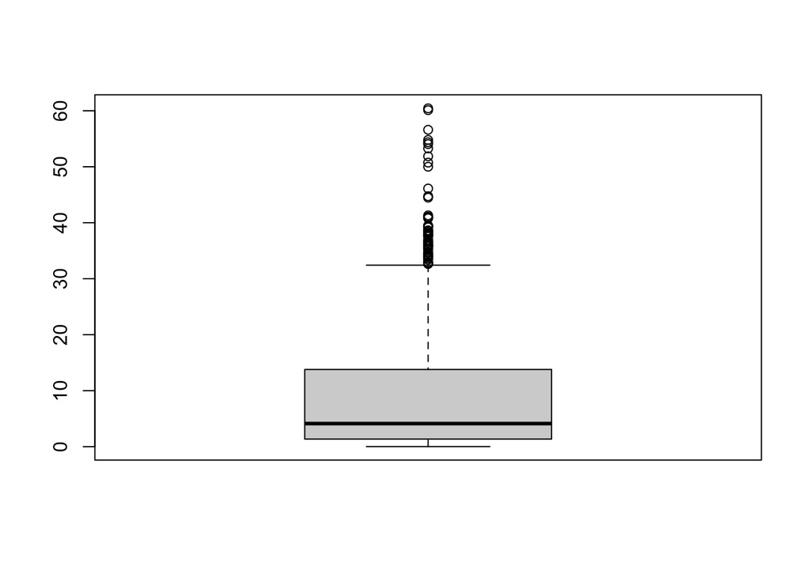

```r
boxplot(df_a_test$APE_lag168)
```

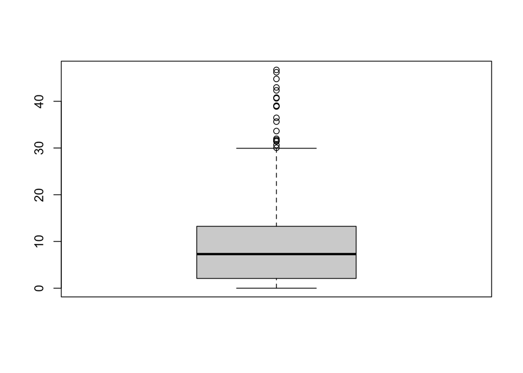

```r
boxplot(df_a_test$APE_lag48)
```

# 4 TASK B

Preparing data set

```r
df_b <- df %>%
  mutate(lag168 = lag(consumption, 168),
         lag48 = lag(consumption, 48),
         id = row_number()) %>%
  filter(id > 168) %>% select(-id)
head(df_b)
```

```
## # A tibble: 6 x 5
##   date       hour  consumption lag168 lag48
##   <date>     <chr>       <dbl>  <dbl> <dbl>
## 1 2016-01-08 00           28.6   26.3  29.2
## 2 2016-01-08 01           27.1   25.0  27.6
## 3 2016-01-08 02           26.0   23.5  26.6
## 4 2016-01-08 03           25.3   22.5  25.7
## 5 2016-01-08 04           25.1   22.0  25.9
## 6 2016-01-08 05           25.4   22.0  25.9
```

Filtering train and test set

```r
df_b_train <- df_b %>% filter(date < as_date('2020-03-01'))
df_b_test <- df_b %>% filter(date >= as_date('2020-03-01'))
```

Training linear regression model

```r
model_b <- lm(consumption ~ lag168 + lag48, data = df_b_train)
summary(model_b)
```

```
##
## Call:
## lm(formula = consumption ~ lag168 + lag48, data = df_b_train)
##
## Residuals:
##      Min       1Q   Median       3Q      Max
## -16.8618  -0.9762  -0.0071   0.9943  16.0710
##
## Coefficients:
##             Estimate Std. Error t value            Pr(>|t|)
## (Intercept) 1.620347   0.091840   17.64 <0.0000000000000002 ***
## lag168      0.641303   0.003333  192.40 <0.0000000000000002 ***
## lag48       0.309600   0.003337   92.77 <0.0000000000000002 ***
## ---
## Signif. codes:  0 '***' 0.001 '**' 0.01 '*' 0.05 '.' 0.1 ' ' 1
##
## Residual standard error: 2.366 on 36333 degrees of freedom
## Multiple R-squared:  0.7686, Adjusted R-squared:  0.7685
## F-statistic: 6.033e+04 on 2 and 36333 DF,  p-value: < 0.00000000000000022
```

Testing model on the test set

```r
df_b_test_pred <- predict(model_b, newdata = df_b_test)
```

Summary statistics of MAPE values for the test period

```r
df_b_test_APE <- (abs(df_b_test$consumption-df_b_test_pred) / abs(df_b_test$consumption)) * 100
summary(df_b_test_APE)
```

```
##     Min.  1st Qu.   Median     Mean  3rd Qu.     Max.
##  0.00032  1.43015  3.26185  5.16261  6.47155 70.64570
```

# 5 TASK C

Establishing a model for each hour

```r
model_c_h0 <- lm(consumption ~ lag168 + lag48, data = df_b_train %>% filter(hour == "00"))
model_c_h1 <- lm(consumption ~ lag168 + lag48, data = df_b_train %>% filter(hour == "01"))
model_c_h2 <- lm(consumption ~ lag168 + lag48, data = df_b_train %>% filter(hour == "02"))
model_c_h3 <- lm(consumption ~ lag168 + lag48, data = df_b_train %>% filter(hour == "03"))
model_c_h4 <- lm(consumption ~ lag168 + lag48, data = df_b_train %>% filter(hour == "04"))
model_c_h5 <- lm(consumption ~ lag168 + lag48, data = df_b_train %>% filter(hour == "05"))
model_c_h6 <- lm(consumption ~ lag168 + lag48, data = df_b_train %>% filter(hour == "06"))
model_c_h7 <- lm(consumption ~ lag168 + lag48, data = df_b_train %>% filter(hour == "07"))
model_c_h8 <- lm(consumption ~ lag168 + lag48, data = df_b_train %>% filter(hour == "08"))
model_c_h9 <- lm(consumption ~ lag168 + lag48, data = df_b_train %>% filter(hour == "09"))
model_c_h10 <- lm(consumption ~ lag168 + lag48, data = df_b_train %>% filter(hour == "10"))
model_c_h11 <- lm(consumption ~ lag168 + lag48, data = df_b_train %>% filter(hour == "11"))
model_c_h12 <- lm(consumption ~ lag168 + lag48, data = df_b_train %>% filter(hour == "12"))
model_c_h13 <- lm(consumption ~ lag168 + lag48, data = df_b_train %>% filter(hour == "13"))
model_c_h14 <- lm(consumption ~ lag168 + lag48, data = df_b_train %>% filter(hour == "14"))
model_c_h15 <- lm(consumption ~ lag168 + lag48, data = df_b_train %>% filter(hour == "15"))
model_c_h16 <- lm(consumption ~ lag168 + lag48, data = df_b_train %>% filter(hour == "16"))
model_c_h17 <- lm(consumption ~ lag168 + lag48, data = df_b_train %>% filter(hour == "17"))
model_c_h18 <- lm(consumption ~ lag168 + lag48, data = df_b_train %>% filter(hour == "18"))
model_c_h19 <- lm(consumption ~ lag168 + lag48, data = df_b_train %>% filter(hour == "19"))
model_c_h20 <- lm(consumption ~ lag168 + lag48, data = df_b_train %>% filter(hour == "20"))
model_c_h21 <- lm(consumption ~ lag168 + lag48, data = df_b_train %>% filter(hour == "21"))
model_c_h22 <- lm(consumption ~ lag168 + lag48, data = df_b_train %>% filter(hour == "22"))
model_c_h23 <- lm(consumption ~ lag168 + lag48, data = df_b_train %>% filter(hour == "23"))
```

Preparing test sets

```r
df_c_test_h0 <- df_b_test %>% filter(hour == "00")
df_c_test_h1 <- df_b_test %>% filter(hour == "01")
df_c_test_h2 <- df_b_test %>% filter(hour == "02")
df_c_test_h3 <- df_b_test %>% filter(hour == "03")
df_c_test_h4 <- df_b_test %>% filter(hour == "04")
df_c_test_h5 <- df_b_test %>% filter(hour == "05")
df_c_test_h6 <- df_b_test %>% filter(hour == "06")
df_c_test_h7 <- df_b_test %>% filter(hour == "07")
df_c_test_h8 <- df_b_test %>% filter(hour == "08")
df_c_test_h9 <- df_b_test %>% filter(hour == "09")
df_c_test_h10 <- df_b_test %>% filter(hour == "10")
df_c_test_h11 <- df_b_test %>% filter(hour == "11")
df_c_test_h12 <- df_b_test %>% filter(hour == "12")
df_c_test_h13 <- df_b_test %>% filter(hour == "13")
df_c_test_h14 <- df_b_test %>% filter(hour == "14")
df_c_test_h15 <- df_b_test %>% filter(hour == "15")
df_c_test_h16 <- df_b_test %>% filter(hour == "16")
df_c_test_h17 <- df_b_test %>% filter(hour == "17")
df_c_test_h18 <- df_b_test %>% filter(hour == "18")
df_c_test_h19 <- df_b_test %>% filter(hour == "19")
df_c_test_h20 <- df_b_test %>% filter(hour == "20")
df_c_test_h21 <- df_b_test %>% filter(hour == "21")
df_c_test_h22 <- df_b_test %>% filter(hour == "22")
df_c_test_h23 <- df_b_test %>% filter(hour == "23")
```

Preparing test predictions and testing models on the test sets

Hour 0

```r
df_c_test_pred_h0 <- predict(model_c_h0, newdata = df_c_test_h0)
summary((abs(df_c_test_h0$consumption-df_c_test_pred_h0) / abs(df_c_test_h0$consumption)) * 100)
```

```
##     Min.  1st Qu.   Median     Mean  3rd Qu.     Max.
##  0.01593  1.28406  2.87981  3.78658  5.04444 34.37125
```

Hour 1

```r
df_c_test_pred_h1 <- predict(model_c_h1, newdata = df_c_test_h1)
summary((abs(df_c_test_h1$consumption-df_c_test_pred_h1) / abs(df_c_test_h1$consumption)) * 100)
```

```
##     Min.  1st Qu.   Median     Mean  3rd Qu.     Max.
##  0.00013  1.39850  3.04308  3.85883  5.04794 37.39438
```

Hour 2

```r
df_c_test_pred_h2 <- predict(model_c_h2, newdata = df_c_test_h2)
summary((abs(df_c_test_h2$consumption-df_c_test_pred_h2) / abs(df_c_test_h2$consumption)) * 100)
```

```
##     Min.  1st Qu.   Median     Mean  3rd Qu.     Max.
##  0.01709  1.42186  3.18343  4.00081  5.07005 42.09022
```

Hour 3

```r
df_c_test_pred_h3 <- predict(model_c_h3, newdata = df_c_test_h3)
summary((abs(df_c_test_h3$consumption-df_c_test_pred_h3) / abs(df_c_test_h3$consumption)) * 100)
```

```
##     Min.  1st Qu.   Median     Mean  3rd Qu.     Max.
##  0.00962  1.41363  3.19733  4.00704  5.04194 42.29648
```

Hour 4

```r
df_c_test_pred_h4 <- predict(model_c_h4, newdata = df_c_test_h4)
summary((abs(df_c_test_h4$consumption-df_c_test_pred_h4) / abs(df_c_test_h4$consumption)) * 100)
```

```
##     Min.  1st Qu.   Median     Mean  3rd Qu.     Max.
##  0.00099  1.36735  3.16807  4.02073  5.21401 39.63823
```

Hour 5

```r
df_c_test_pred_h5 <- predict(model_c_h5, newdata = df_c_test_h5)
summary((abs(df_c_test_h5$consumption-df_c_test_pred_h5) / abs(df_c_test_h5$consumption)) * 100)
```

```
##     Min.  1st Qu.   Median     Mean  3rd Qu.     Max.
##  0.01425  1.36166  3.07787  4.06610  5.14284 37.81037
```

Hour 6

```r
df_c_test_pred_h6 <- predict(model_c_h6, newdata = df_c_test_h6)
summary((abs(df_c_test_h6$consumption-df_c_test_pred_h6) / abs(df_c_test_h6$consumption)) * 100)
```

```
##     Min.  1st Qu.   Median     Mean  3rd Qu.     Max.
##  0.02556  1.17852  2.93142  4.21977  5.32303 36.95801
```

Hour 7

```r
df_c_test_pred_h7 <- predict(model_c_h7, newdata = df_c_test_h7)
summary((abs(df_c_test_h7$consumption-df_c_test_pred_h7) / abs(df_c_test_h7$consumption)) * 100)
```

```
##     Min.  1st Qu.   Median     Mean  3rd Qu.     Max.
##  0.01688  1.14351  3.27358  4.80102  5.92354 42.11643
```

Hour 8

```r
df_c_test_pred_h8 <- predict(model_c_h8, newdata = df_c_test_h8)
summary((abs(df_c_test_h8$consumption-df_c_test_pred_h8) / abs(df_c_test_h8$consumption)) * 100)
```

```
##     Min.  1st Qu.   Median     Mean  3rd Qu.     Max.
##  0.02045  1.60245  4.02018  6.31676  7.80223 55.87622
```

Hour 9

```r
df_c_test_pred_h9 <- predict(model_c_h9, newdata = df_c_test_h9)
summary((abs(df_c_test_h9$consumption-df_c_test_pred_h9) / abs(df_c_test_h9$consumption)) * 100)
```

```
##     Min.  1st Qu.   Median     Mean  3rd Qu.     Max.
##  0.02288  1.73808  4.80242  7.04288  8.73996 64.92012
```

Hour 10

```r
df_c_test_pred_h10 <- predict(model_c_h10, newdata = df_c_test_h10)
summary((abs(df_c_test_h10$consumption-df_c_test_pred_h10) / abs(df_c_test_h10$consumption)) * 100)
```

```
##     Min.  1st Qu.   Median     Mean  3rd Qu.     Max.
##  0.02527  1.99417  5.05555  7.16089  9.21311 68.93167
```

Hour 11

```r
df_c_test_pred_h11 <- predict(model_c_h11, newdata = df_c_test_h11)
summary((abs(df_c_test_h11$consumption-df_c_test_pred_h11) / abs(df_c_test_h11$consumption)) * 100)
```

```
##     Min.  1st Qu.   Median     Mean  3rd Qu.     Max.
##  0.03407  2.06986  4.97892  7.17153  9.27173 69.36252
```

Hour 12

```r
df_c_test_pred_h12 <- predict(model_c_h12, newdata = df_c_test_h12)
summary((abs(df_c_test_h12$consumption-df_c_test_pred_h12) / abs(df_c_test_h12$consumption)) * 100)
```

```
##     Min.  1st Qu.   Median     Mean  3rd Qu.     Max.
##  0.00683  2.22736  4.68112  6.91624  8.91640 61.98122
```

Hour 13

```r
df_c_test_pred_h13 <- predict(model_c_h13, newdata = df_c_test_h13)
summary((abs(df_c_test_h13$consumption-df_c_test_pred_h13) / abs(df_c_test_h13$consumption)) * 100)
```

```
##    Min. 1st Qu.  Median    Mean 3rd Qu.    Max.
##  0.0021  2.2233  4.8946  6.9025  8.9137 59.9993
```

Hour 14

```r
df_c_test_pred_h14 <- predict(model_c_h14, newdata = df_c_test_h14)
summary((abs(df_c_test_h14$consumption-df_c_test_pred_h14) / abs(df_c_test_h14$consumption)) * 100)
```

```
##     Min.  1st Qu.   Median     Mean  3rd Qu.     Max.
##  0.01262  2.44287  4.91718  7.04970  8.81801 65.88618
```

Hour 15

```r
df_c_test_pred_h15 <- predict(model_c_h15, newdata = df_c_test_h15)
summary((abs(df_c_test_h15$consumption-df_c_test_pred_h15) / abs(df_c_test_h15$consumption)) * 100)
```

```
##     Min.  1st Qu.   Median     Mean  3rd Qu.     Max.
##  0.01245  2.21056  5.01954  6.85168  8.63032 70.97205
```

Hour 16

```r
df_c_test_pred_h16 <- predict(model_c_h16, newdata = df_c_test_h16)
summary((abs(df_c_test_h16$consumption-df_c_test_pred_h16) / abs(df_c_test_h16$consumption)) * 100)
```

```
##     Min.  1st Qu.   Median     Mean  3rd Qu.     Max.
##  0.01299  1.99664  4.64222  6.44090  7.91107 67.05177
```

Hour 17

```r
df_c_test_pred_h17 <- predict(model_c_h17, newdata = df_c_test_h17)
summary((abs(df_c_test_h17$consumption-df_c_test_pred_h17) / abs(df_c_test_h17$consumption)) * 100)
```

```
##     Min.  1st Qu.   Median     Mean  3rd Qu.     Max.
##  0.00024  1.90851  4.16724  5.76815  7.16624 60.32857
```

Hour 18

```r
df_c_test_pred_h18 <- predict(model_c_h18, newdata = df_c_test_h18)
summary((abs(df_c_test_h18$consumption-df_c_test_pred_h18) / abs(df_c_test_h18$consumption)) * 100)
```

```
##     Min.  1st Qu.   Median     Mean  3rd Qu.     Max.
##  0.00083  1.62040  3.42900  4.80428  6.03650 52.83224
```

Hour 19

```r
df_c_test_pred_h19 <- predict(model_c_h19, newdata = df_c_test_h19)
summary((abs(df_c_test_h19$consumption-df_c_test_pred_h19) / abs(df_c_test_h19$consumption)) * 100)
```

```
##     Min.  1st Qu.   Median     Mean  3rd Qu.     Max.
##  0.03327  1.38389  3.11553  4.24553  5.25850 48.11373
```

Hour 20

```r
df_c_test_pred_h20 <- predict(model_c_h20, newdata = df_c_test_h20)
summary((abs(df_c_test_h20$consumption-df_c_test_pred_h20) / abs(df_c_test_h20$consumption)) * 100)
```

```
##     Min.  1st Qu.   Median     Mean  3rd Qu.     Max.
##  0.00761  1.38559  2.88003  3.86372  4.97286 36.01662
```

Hour 21

```r
df_c_test_pred_h21 <- predict(model_c_h21, newdata = df_c_test_h21)
summary((abs(df_c_test_h21$consumption-df_c_test_pred_h21) / abs(df_c_test_h21$consumption)) * 100)
```

```
##     Min.  1st Qu.   Median     Mean  3rd Qu.     Max.
##  0.00112  1.33481  2.87045  3.86682  5.09998 35.01364
```

Hour 22

```r
df_c_test_pred_h22 <- predict(model_c_h22, newdata = df_c_test_h22)
summary((abs(df_c_test_h22$consumption-df_c_test_pred_h22) / abs(df_c_test_h22$consumption)) * 100)
```

```
##     Min.  1st Qu.   Median     Mean  3rd Qu.     Max.
##  0.00084  1.38538  2.99356  3.90001  5.21312 35.36761
```

Hour 23

```r
df_c_test_pred_h23 <- predict(model_c_h23, newdata = df_c_test_h23)
summary((abs(df_c_test_h23$consumption-df_c_test_pred_h23) / abs(df_c_test_h23$consumption)) * 100)
```

```
##     Min.  1st Qu.   Median     Mean  3rd Qu.     Max.
##  0.00119  1.35772  2.86544  3.87160  5.09514 34.18099
```

# 6 TASK D

Preparing feature matrix and target data set

```r
df_d <- df %>%
  mutate(lag_day7 = lag(consumption, 168),
         lag_day2 = lag(consumption, 48),
         id = row_number()) %>%
  filter(id > 168) %>% select(-id)

df_d_matrix <- df_d %>% select(-consumption) %>% pivot_wider(names_from = hour, values_from = c(lag_day7, lag_day2))

df_d_matrix_train <- df_d_matrix %>% filter(date < as_date('2020-03-01')) %>% select(-date) %>%  as.matrix()
df_d_matrix_test <- df_d_matrix %>% filter(date >= as_date('2020-03-01')) %>% select(-date) %>% as.matrix()
head(df_d_matrix_train)
```

```
##      lag_day7_00 lag_day7_01 lag_day7_02 lag_day7_03 lag_day7_04 lag_day7_05
## [1,]    26.27724    24.99182    23.53261    22.46478    22.00291    21.95708
## [2,]    26.22460    24.70858    23.77158    22.92129    22.87089    23.32563
## [3,]    27.61396    25.77928    24.56631    23.87842    23.51138    23.67232
## [4,]    27.10309    25.43984    24.39507    23.96103    23.86063    24.41847
## [5,]    29.24438    27.63723    26.33578    25.87023    25.97507    26.31848
## [6,]    29.18927    27.61402    26.57897    25.71919    25.86463    25.91859
##      lag_day7_06 lag_day7_07 lag_day7_08 lag_day7_09 lag_day7_10 lag_day7_11
## [1,]    22.20354    21.84416    23.09473    25.20227    27.22496    28.90804
## [2,]    23.60498    24.02270    26.93048    30.04360    32.10238    33.43189
## [3,]    23.82708    23.40511    24.63872    26.80238    28.77988    30.20430
## [4,]    25.70859    27.45539    32.98207    37.17584    38.60667    39.65957
## [5,]    27.10929    28.57022    33.10600    36.65712    37.77649    38.66422
## [6,]    27.09194    28.53305    33.20334    36.25722    37.21291    37.84474
##      lag_day7_12 lag_day7_13 lag_day7_14 lag_day7_15 lag_day7_16 lag_day7_17
```

[output cut: 41 more lines]

```r
df_d_target_train <- df_d %>% select(date, hour, consumption) %>% filter(date < as_date('2020-03-01'))
df_d_target_test <- df_d %>% select(date, hour, consumption) %>% filter(date >= as_date('2020-03-01'))
head(df_d_target_train)
```

```
## # A tibble: 6 x 3
##   date       hour  consumption
##   <date>     <chr>       <dbl>
## 1 2016-01-08 00           28.6
## 2 2016-01-08 01           27.1
## 3 2016-01-08 02           26.0
## 4 2016-01-08 03           25.3
## 5 2016-01-08 04           25.1
## 6 2016-01-08 05           25.4
```

Establishing lasso regression models by using feature matrix and target variables for each hour

```r
model_d_h0 <- cv.glmnet(df_d_matrix_train, df_d_target_train %>% filter(hour == "00") %>% pull(consumption), type.measure = "mse")
model_d_h1 <- cv.glmnet(df_d_matrix_train, df_d_target_train %>% filter(hour == "01") %>% pull(consumption), type.measure = "mse")
model_d_h2 <- cv.glmnet(df_d_matrix_train, df_d_target_train %>% filter(hour == "02") %>% pull(consumption), type.measure = "mse")
model_d_h3 <- cv.glmnet(df_d_matrix_train, df_d_target_train %>% filter(hour == "03") %>% pull(consumption), type.measure = "mse")
model_d_h4 <- cv.glmnet(df_d_matrix_train, df_d_target_train %>% filter(hour == "04") %>% pull(consumption), type.measure = "mse")
model_d_h5 <- cv.glmnet(df_d_matrix_train, df_d_target_train %>% filter(hour == "05") %>% pull(consumption), type.measure = "mse")
model_d_h6 <- cv.glmnet(df_d_matrix_train, df_d_target_train %>% filter(hour == "06") %>% pull(consumption), type.measure = "mse")
model_d_h7 <- cv.glmnet(df_d_matrix_train, df_d_target_train %>% filter(hour == "07") %>% pull(consumption), type.measure = "mse")
model_d_h8 <- cv.glmnet(df_d_matrix_train, df_d_target_train %>% filter(hour == "08") %>% pull(consumption), type.measure = "mse")
model_d_h9 <- cv.glmnet(df_d_matrix_train, df_d_target_train %>% filter(hour == "09") %>% pull(consumption), type.measure = "mse")
model_d_h10 <- cv.glmnet(df_d_matrix_train, df_d_target_train %>% filter(hour == "10") %>% pull(consumption), type.measure = "mse")
model_d_h11 <- cv.glmnet(df_d_matrix_train, df_d_target_train %>% filter(hour == "11") %>% pull(consumption), type.measure = "mse")
model_d_h12 <- cv.glmnet(df_d_matrix_train, df_d_target_train %>% filter(hour == "12") %>% pull(consumption), type.measure = "mse")
model_d_h13 <- cv.glmnet(df_d_matrix_train, df_d_target_train %>% filter(hour == "13") %>% pull(consumption), type.measure = "mse")
model_d_h14 <- cv.glmnet(df_d_matrix_train, df_d_target_train %>% filter(hour == "14") %>% pull(consumption), type.measure = "mse")
model_d_h15 <- cv.glmnet(df_d_matrix_train, df_d_target_train %>% filter(hour == "15") %>% pull(consumption), type.measure = "mse")
model_d_h16 <- cv.glmnet(df_d_matrix_train, df_d_target_train %>% filter(hour == "16") %>% pull(consumption), type.measure = "mse")
model_d_h17 <- cv.glmnet(df_d_matrix_train, df_d_target_train %>% filter(hour == "17") %>% pull(consumption), type.measure = "mse")
model_d_h18 <- cv.glmnet(df_d_matrix_train, df_d_target_train %>% filter(hour == "18") %>% pull(consumption), type.measure = "mse")
model_d_h19 <- cv.glmnet(df_d_matrix_train, df_d_target_train %>% filter(hour == "19") %>% pull(consumption), type.measure = "mse")
model_d_h20 <- cv.glmnet(df_d_matrix_train, df_d_target_train %>% filter(hour == "20") %>% pull(consumption), type.measure = "mse")
model_d_h21 <- cv.glmnet(df_d_matrix_train, df_d_target_train %>% filter(hour == "21") %>% pull(consumption), type.measure = "mse")
model_d_h22 <- cv.glmnet(df_d_matrix_train, df_d_target_train %>% filter(hour == "22") %>% pull(consumption), type.measure = "mse")
model_d_h23 <- cv.glmnet(df_d_matrix_train, df_d_target_train %>% filter(hour == "23") %>% pull(consumption), type.measure = "mse")
```

Preparing test set realizations

```r
df_d_target_test_h0 <- df_d_target_test %>% filter(hour == "00")
df_d_target_test_h1 <- df_d_target_test %>% filter(hour == "01")
df_d_target_test_h2 <- df_d_target_test %>% filter(hour == "02")
df_d_target_test_h3 <- df_d_target_test %>% filter(hour == "03")
df_d_target_test_h4 <- df_d_target_test %>% filter(hour == "04")
df_d_target_test_h5 <- df_d_target_test %>% filter(hour == "05")
df_d_target_test_h6 <- df_d_target_test %>% filter(hour == "06")
df_d_target_test_h7 <- df_d_target_test %>% filter(hour == "07")
df_d_target_test_h8 <- df_d_target_test %>% filter(hour == "08")
df_d_target_test_h9 <- df_d_target_test %>% filter(hour == "09")
df_d_target_test_h10 <- df_d_target_test %>% filter(hour == "10")
df_d_target_test_h11 <- df_d_target_test %>% filter(hour == "11")
df_d_target_test_h12 <- df_d_target_test %>% filter(hour == "12")
df_d_target_test_h13 <- df_d_target_test %>% filter(hour == "13")
df_d_target_test_h14 <- df_d_target_test %>% filter(hour == "14")
df_d_target_test_h15 <- df_d_target_test %>% filter(hour == "15")
df_d_target_test_h16 <- df_d_target_test %>% filter(hour == "16")
df_d_target_test_h17 <- df_d_target_test %>% filter(hour == "17")
df_d_target_test_h18 <- df_d_target_test %>% filter(hour == "18")
df_d_target_test_h19 <- df_d_target_test %>% filter(hour == "19")
df_d_target_test_h20 <- df_d_target_test %>% filter(hour == "20")
df_d_target_test_h21 <- df_d_target_test %>% filter(hour == "21")
df_d_target_test_h22 <- df_d_target_test %>% filter(hour == "22")
df_d_target_test_h23 <- df_d_target_test %>% filter(hour == "23")
```

Preparing test predictions and testing models on the test sets also stating model coefficients

Hour 0

```r
df_d_test_pred_h0 <- predict(model_d_h0, df_d_matrix_test, s = "lambda.min")
summary((abs(df_d_target_test_h0$consumption-df_d_test_pred_h0) / abs(df_d_target_test_h0$consumption)) * 100)
```

```
##        1
##  Min.   : 0.003802
##  1st Qu.: 0.754791
##  Median : 1.849459
##  Mean   : 2.427965
##  3rd Qu.: 3.226268
##  Max.   :18.473193
```

```r
coef(model_d_h0, s = "lambda.min")
```

```
## 49 x 1 sparse Matrix of class "dgCMatrix"
##                           1
## (Intercept)  2.154633640078
## lag_day7_00  0.104653317521
## lag_day7_01  0.121777850574
## lag_day7_02 -0.103730760395
## lag_day7_03 -0.105398561655
## lag_day7_04  .
## lag_day7_05  .
## lag_day7_06  0.156424700447
## lag_day7_07  0.233443708738
## lag_day7_08  .
## lag_day7_09 -0.060587271770
## lag_day7_10  .
## lag_day7_11  0.000547819615
## lag_day7_12  0.014101673397
## lag_day7_13 -0.000000824029
## lag_day7_14  0.088927691068
## lag_day7_15  0.057648427958
## lag_day7_16  .
## lag_day7_17 -0.073978099196
## lag_day7_18 -0.011232682946
## lag_day7_19 -0.137699960435
## lag_day7_20 -0.212861132451
## lag_day7_21  0.004791130873
## lag_day7_22 -0.055640441416
## lag_day7_23  0.040367884328
## lag_day2_00 -0.302864548053
## lag_day2_01 -0.191434134171
## lag_day2_02 -0.120799091285
## lag_day2_03  0.000104742098
## lag_day2_04  0.399941902566
## lag_day2_05  .
## lag_day2_06 -0.010528062460
## lag_day2_07  0.438195891554
## lag_day2_08  .
## lag_day2_09 -0.573105884746
## lag_day2_10 -0.245326344426
## lag_day2_11 -0.181793515906
## lag_day2_12  0.139621364955
## lag_day2_13  0.561780916654
## lag_day2_14 -0.427251952423
## lag_day2_15  0.099581580421
## lag_day2_16  0.204262916004
## lag_day2_17  0.005481839061
## lag_day2_18 -0.064989150098
## lag_day2_19  .
## lag_day2_20 -0.260514243581
## lag_day2_21  0.175876978829
## lag_day2_22  0.313822473834
## lag_day2_23  1.029750398209
```

Hour 1

```r
df_d_test_pred_h1 <- predict(model_d_h1, df_d_matrix_test, s = "lambda.min")
summary((abs(df_d_target_test_h1$consumption-df_d_test_pred_h1) / abs(df_d_target_test_h1$consumption)) * 100)
```

```
##        1
##  Min.   : 0.03963
##  1st Qu.: 0.84238
##  Median : 1.97746
##  Mean   : 2.56888
##  3rd Qu.: 3.42110
##  Max.   :22.12570
```

```r
coef(model_d_h1, s = "lambda.min")
```

```
## 49 x 1 sparse Matrix of class "dgCMatrix"
##                        1
## (Intercept)  2.329935589
## lag_day7_00  .
## lag_day7_01  0.120071641
## lag_day7_02 -0.031411735
## lag_day7_03 -0.072975964
## lag_day7_04  .
## lag_day7_05  .
## lag_day7_06  0.148336985
## lag_day7_07  0.229129669
## lag_day7_08  0.013958237
## lag_day7_09 -0.070277675
## lag_day7_10  .
## lag_day7_11  .
## lag_day7_12  .
## lag_day7_13  0.011771362
## lag_day7_14  0.047996452
## lag_day7_15  0.113501608
## lag_day7_16  0.002014001
## lag_day7_17 -0.073769310
## lag_day7_18 -0.028843809
## lag_day7_19 -0.138823670
## lag_day7_20 -0.202123592
## lag_day7_21  0.032939629
## lag_day7_22 -0.066497829
## lag_day7_23  0.024753240
## lag_day2_00 -0.516455163
## lag_day2_01 -0.058835536
## lag_day2_02 -0.056740767
## lag_day2_03  0.061375044
## lag_day2_04  0.419572501
## lag_day2_05 -0.004946629
## lag_day2_06 -0.039509603
## lag_day2_07  0.399649576
## lag_day2_08  0.028887857
## lag_day2_09 -0.500325872
## lag_day2_10 -0.246588847
## lag_day2_11 -0.310395691
## lag_day2_12  0.158382153
## lag_day2_13  0.504863438
## lag_day2_14 -0.294578362
## lag_day2_15  0.095847852
## lag_day2_16  0.169785751
## lag_day2_17  .
## lag_day2_18 -0.059027013
## lag_day2_19  0.044482533
## lag_day2_20 -0.321479486
## lag_day2_21  0.138069823
## lag_day2_22  0.310738608
## lag_day2_23  1.041669687
```

Hour 2

```r
df_d_test_pred_h2 <- predict(model_d_h2, df_d_matrix_test, s = "lambda.min")
summary((abs(df_d_target_test_h2$consumption-df_d_test_pred_h2) / abs(df_d_target_test_h2$consumption)) * 100)
```

```
##        1
##  Min.   : 0.02127
##  1st Qu.: 0.99015
##  Median : 2.10642
##  Mean   : 2.75757
##  3rd Qu.: 3.61055
##  Max.   :26.81328
```

```r
coef(model_d_h2, s = "lambda.min")
```

```
## 49 x 1 sparse Matrix of class "dgCMatrix"
##                        1
## (Intercept)  2.648041855
## lag_day7_00  .
## lag_day7_01  0.021417612
## lag_day7_02  .
## lag_day7_03  .
## lag_day7_04  .
## lag_day7_05  .
## lag_day7_06  0.073333854
## lag_day7_07  0.288175182
## lag_day7_08  0.023886098
## lag_day7_09 -0.074249082
## lag_day7_10 -0.002489367
## lag_day7_11 -0.003114002
## lag_day7_12  .
## lag_day7_13  0.033709241
## lag_day7_14  0.007720247
## lag_day7_15  0.115660763
## lag_day7_16  .
## lag_day7_17 -0.016214953
## lag_day7_18 -0.092293602
## lag_day7_19 -0.131993689
## lag_day7_20 -0.133761338
## lag_day7_21  0.002966736
## lag_day7_22 -0.070851105
## lag_day7_23  0.011570884
## lag_day2_00 -0.644301639
## lag_day2_01 -0.158386350
## lag_day2_02  .
## lag_day2_03  0.157116196
## lag_day2_04  0.562425900
## lag_day2_05 -0.009904473
## lag_day2_06 -0.046386211
## lag_day2_07  0.339338271
## lag_day2_08  0.015103832
## lag_day2_09 -0.456892491
## lag_day2_10 -0.235748255
## lag_day2_11 -0.292474219
## lag_day2_12  0.079581852
## lag_day2_13  0.501688286
## lag_day2_14 -0.217111498
## lag_day2_15  0.055806633
## lag_day2_16  0.145933874
## lag_day2_17  .
## lag_day2_18 -0.050098937
## lag_day2_19  0.100936147
## lag_day2_20 -0.417352002
## lag_day2_21  0.215306000
## lag_day2_22  0.276497192
## lag_day2_23  1.023167196
```

Hour 3

```r
df_d_test_pred_h3 <- predict(model_d_h3, df_d_matrix_test, s = "lambda.min")
summary((abs(df_d_target_test_h3$consumption-df_d_test_pred_h3) / abs(df_d_target_test_h3$consumption)) * 100)
```

```
##        1
##  Min.   : 0.02773
##  1st Qu.: 0.89022
##  Median : 2.05213
##  Mean   : 2.78150
##  3rd Qu.: 3.64426
##  Max.   :29.28479
```

```r
coef(model_d_h3, s = "lambda.min")
```

```
## 49 x 1 sparse Matrix of class "dgCMatrix"
##                        1
## (Intercept)  2.492514659
## lag_day7_00  .
## lag_day7_01  .
## lag_day7_02 -0.012564155
## lag_day7_03  .
## lag_day7_04 -0.010485505
## lag_day7_05  .
## lag_day7_06  0.097288820
## lag_day7_07  0.294324806
## lag_day7_08  0.008344450
## lag_day7_09 -0.047055290
## lag_day7_10 -0.015874873
## lag_day7_11  .
## lag_day7_12 -0.005678303
## lag_day7_13  0.031435999
## lag_day7_14  0.029108816
## lag_day7_15  0.108812735
## lag_day7_16  .
## lag_day7_17 -0.013872881
## lag_day7_18 -0.106542227
## lag_day7_19 -0.106998090
## lag_day7_20 -0.164218028
## lag_day7_21  .
## lag_day7_22 -0.033687584
## lag_day7_23  .
## lag_day2_00 -0.648247283
## lag_day2_01 -0.223735089
## lag_day2_02  .
## lag_day2_03  0.160545413
## lag_day2_04  0.624601931
## lag_day2_05  .
## lag_day2_06 -0.006957931
## lag_day2_07  0.287458243
## lag_day2_08  .
## lag_day2_09 -0.449285164
## lag_day2_10 -0.222293222
## lag_day2_11 -0.245377924
## lag_day2_12  0.022122251
## lag_day2_13  0.499558454
## lag_day2_14 -0.168073631
## lag_day2_15  0.029853298
## lag_day2_16  0.113567834
## lag_day2_17  .
## lag_day2_18 -0.009357203
## lag_day2_19  0.022382741
## lag_day2_20 -0.277730456
## lag_day2_21  0.187194305
## lag_day2_22  0.228182337
## lag_day2_23  1.000353497
```

Hour 4

```r
df_d_test_pred_h4 <- predict(model_d_h4, df_d_matrix_test, s = "lambda.min")
summary((abs(df_d_target_test_h4$consumption-df_d_test_pred_h4) / abs(df_d_target_test_h4$consumption)) * 100)
```

```
##        1
##  Min.   : 0.01418
##  1st Qu.: 0.90242
##  Median : 2.02813
##  Mean   : 2.82775
##  3rd Qu.: 3.74681
##  Max.   :27.79391
```

```r
coef(model_d_h4, s = "lambda.min")
```

```
## 49 x 1 sparse Matrix of class "dgCMatrix"
##                        1
## (Intercept)  2.583131353
## lag_day7_00  .
## lag_day7_01  0.006067225
## lag_day7_02 -0.053259742
## lag_day7_03  .
## lag_day7_04  .
## lag_day7_05  .
## lag_day7_06  0.115628532
## lag_day7_07  0.306527678
## lag_day7_08  0.004934980
## lag_day7_09 -0.032034960
## lag_day7_10  .
## lag_day7_11 -0.040092435
## lag_day7_12 -0.027000366
## lag_day7_13  0.035815060
## lag_day7_14  0.050520008
## lag_day7_15  0.119195344
## lag_day7_16  .
## lag_day7_17 -0.043251692
## lag_day7_18 -0.041744084
## lag_day7_19 -0.143798341
## lag_day7_20 -0.177384085
## lag_day7_21  .
## lag_day7_22 -0.026678584
## lag_day7_23  .
## lag_day2_00 -0.552781081
## lag_day2_01 -0.345843437
## lag_day2_02 -0.187110240
## lag_day2_03  0.130957723
## lag_day2_04  0.808986087
## lag_day2_05  0.080760017
## lag_day2_06 -0.002904745
## lag_day2_07  0.271494014
## lag_day2_08  0.001387809
## lag_day2_09 -0.483714027
## lag_day2_10 -0.163209795
## lag_day2_11 -0.257301766
## lag_day2_12  0.003061465
## lag_day2_13  0.583070255
## lag_day2_14 -0.269793772
## lag_day2_15  0.069579272
## lag_day2_16  0.103202942
## lag_day2_17  .
## lag_day2_18 -0.036730942
## lag_day2_19  .
## lag_day2_20 -0.130437158
## lag_day2_21  0.139867155
## lag_day2_22  0.227682981
## lag_day2_23  0.924925359
```

Hour 5

```r
df_d_test_pred_h5 <- predict(model_d_h5, df_d_matrix_test, s = "lambda.min")
summary((abs(df_d_target_test_h5$consumption-df_d_test_pred_h5) / abs(df_d_target_test_h5$consumption)) * 100)
```

```
##        1
##  Min.   : 0.006547
##  1st Qu.: 1.072882
##  Median : 2.031397
##  Mean   : 2.888808
##  3rd Qu.: 3.790707
##  Max.   :24.836172
```

```r
coef(model_d_h5, s = "lambda.min")
```

```
## 49 x 1 sparse Matrix of class "dgCMatrix"
##                         1
## (Intercept)  2.2347041555
## lag_day7_00  .
## lag_day7_01  .
## lag_day7_02 -0.0711735271
## lag_day7_03  .
## lag_day7_04 -0.0719242268
## lag_day7_05  .
## lag_day7_06  0.2201937941
## lag_day7_07  0.3294400712
## lag_day7_08  0.0003923296
## lag_day7_09 -0.0354365624
## lag_day7_10  .
## lag_day7_11 -0.0584696046
## lag_day7_12 -0.0068167806
## lag_day7_13  0.0307857153
## lag_day7_14  0.0240364220
## lag_day7_15  0.1421377813
## lag_day7_16  .
## lag_day7_17 -0.0042409883
## lag_day7_18 -0.1003846468
## lag_day7_19 -0.0563129234
## lag_day7_20 -0.2316279872
## lag_day7_21 -0.0209386033
## lag_day7_22 -0.0177219596
## lag_day7_23  .
## lag_day2_00 -0.5637140414
## lag_day2_01 -0.2351044907
## lag_day2_02 -0.3679517827
## lag_day2_03  .
## lag_day2_04  0.4909353312
## lag_day2_05  0.6838266235
## lag_day2_06  .
## lag_day2_07  0.1849519265
## lag_day2_08  .
## lag_day2_09 -0.4641896014
## lag_day2_10 -0.2248166764
## lag_day2_11 -0.1999653974
## lag_day2_12  .
## lag_day2_13  0.6506697691
## lag_day2_14 -0.2793489528
## lag_day2_15  0.0040723169
## lag_day2_16  0.0907121812
## lag_day2_17 -0.0040192049
## lag_day2_18 -0.0059198276
## lag_day2_19  .
## lag_day2_20  0.0101411291
## lag_day2_21  .
## lag_day2_22  0.2836292153
## lag_day2_23  0.8543386022
```

Hour 6

```r
df_d_test_pred_h6 <- predict(model_d_h6, df_d_matrix_test, s = "lambda.min")
summary((abs(df_d_target_test_h6$consumption-df_d_test_pred_h6) / abs(df_d_target_test_h6$consumption)) * 100)
```

```
##        1
##  Min.   : 0.0034
##  1st Qu.: 1.1400
##  Median : 2.0836
##  Mean   : 3.1789
##  3rd Qu.: 3.9367
##  Max.   :26.0739
```

```r
coef(model_d_h6, s = "lambda.min")
```

```
## 49 x 1 sparse Matrix of class "dgCMatrix"
##                           1
## (Intercept)  2.795777969408
## lag_day7_00 -0.000001937307
## lag_day7_01  .
## lag_day7_02 -0.005012594615
## lag_day7_03  .
## lag_day7_04 -0.207870671733
## lag_day7_05 -0.355954356139
## lag_day7_06  0.458777162717
## lag_day7_07  0.514409653009
## lag_day7_08  .
## lag_day7_09 -0.009557413504
## lag_day7_10  .
## lag_day7_11 -0.105794947209
## lag_day7_12 -0.044180426726
## lag_day7_13  .
## lag_day7_14  0.081863586334
## lag_day7_15  0.167634689756
## lag_day7_16  .
## lag_day7_17 -0.002263710532
## lag_day7_18 -0.047985716402
## lag_day7_19  .
## lag_day7_20 -0.349972991224
## lag_day7_21 -0.015887939706
## lag_day7_22 -0.047338851570
## lag_day7_23  .
## lag_day2_00 -0.595461918474
## lag_day2_01 -0.155735482167
## lag_day2_02 -0.407234196223
## lag_day2_03  .
## lag_day2_04  0.518221515510
## lag_day2_05  0.289571968567
## lag_day2_06  0.421069035248
## lag_day2_07  0.152879455953
## lag_day2_08  .
## lag_day2_09 -0.568424963095
## lag_day2_10 -0.189631732154
## lag_day2_11 -0.147352828128
## lag_day2_12  0.007016482120
## lag_day2_13  0.718750601251
## lag_day2_14 -0.319732917607
## lag_day2_15  0.001800153531
## lag_day2_16  0.021913852643
## lag_day2_17 -0.000026274897
## lag_day2_18 -0.015529968171
## lag_day2_19  0.027914688416
## lag_day2_20  0.096463430107
## lag_day2_21  0.027010312682
## lag_day2_22  0.274480703698
## lag_day2_23  0.765159518001
```

Hour 7

```r
df_d_test_pred_h7 <- predict(model_d_h7, df_d_matrix_test, s = "lambda.min")
summary((abs(df_d_target_test_h7$consumption-df_d_test_pred_h7) / abs(df_d_target_test_h7$consumption)) * 100)
```

```
##        1
##  Min.   : 0.01367
##  1st Qu.: 1.19599
##  Median : 2.41913
##  Mean   : 3.81883
##  3rd Qu.: 4.68794
##  Max.   :33.06271
```

```r
coef(model_d_h7, s = "lambda.min")
```

```
## 49 x 1 sparse Matrix of class "dgCMatrix"
##                          1
## (Intercept)  4.17849279189
## lag_day7_00  .
## lag_day7_01  .
## lag_day7_02  .
## lag_day7_03  0.17094162211
## lag_day7_04 -0.28305111402
## lag_day7_05 -0.77758351299
## lag_day7_06  0.14321185747
## lag_day7_07  1.07267279317
## lag_day7_08  0.08278260650
## lag_day7_09 -0.00123446172
## lag_day7_10 -0.01955713755
## lag_day7_11 -0.13714838037
## lag_day7_12 -0.11877101584
## lag_day7_13  .
## lag_day7_14  0.03747745010
## lag_day7_15  0.28333202707
## lag_day7_16  0.02797565917
## lag_day7_17  0.02922087765
## lag_day7_18 -0.08057824618
## lag_day7_19 -0.04852727992
## lag_day7_20 -0.38859157114
## lag_day7_21 -0.03299704653
## lag_day7_22 -0.05900620676
## lag_day7_23  0.03071176855
## lag_day2_00 -0.65331258920
## lag_day2_01 -0.17715359354
## lag_day2_02 -0.64178257300
## lag_day2_03  0.00009252513
## lag_day2_04  0.76206048044
## lag_day2_05  0.52177321536
## lag_day2_06  0.00682592423
## lag_day2_07  0.48173847120
## lag_day2_08  .
## lag_day2_09 -0.80863596699
## lag_day2_10  .
## lag_day2_11 -0.27947791461
## lag_day2_12  0.01195415334
## lag_day2_13  1.11453943553
## lag_day2_14 -0.61135408766
## lag_day2_15  0.00312311028
## lag_day2_16  0.00358019768
## lag_day2_17 -0.00070590246
## lag_day2_18  0.00341324512
## lag_day2_19  .
## lag_day2_20  0.17876282428
## lag_day2_21  0.05106752265
## lag_day2_22  0.19067631568
## lag_day2_23  0.85801897971
```

Hour 8

```r
df_d_test_pred_h8 <- predict(model_d_h8, df_d_matrix_test, s = "lambda.min")
summary((abs(df_d_target_test_h8$consumption-df_d_test_pred_h8) / abs(df_d_target_test_h8$consumption)) * 100)
```

```
##        1
##  Min.   : 0.00262
##  1st Qu.: 1.55290
##  Median : 3.38761
##  Mean   : 5.37742
##  3rd Qu.: 6.44363
##  Max.   :50.48861
```

```r
coef(model_d_h8, s = "lambda.min")
```

```
## 49 x 1 sparse Matrix of class "dgCMatrix"
##                          1
## (Intercept)  7.22739200794
## lag_day7_00  0.05823747740
## lag_day7_01  0.06604139683
## lag_day7_02  .
## lag_day7_03  0.23553894183
## lag_day7_04 -0.33655701175
## lag_day7_05 -1.26766744050
## lag_day7_06  0.06287197017
## lag_day7_07  0.89224814749
## lag_day7_08  0.66686117161
## lag_day7_09  0.00042912972
## lag_day7_10  .
## lag_day7_11 -0.23416544014
## lag_day7_12 -0.12344270606
## lag_day7_13  0.00004438765
## lag_day7_14  0.10151083279
## lag_day7_15  0.17513241388
## lag_day7_16  0.15859694725
## lag_day7_17  0.18303121621
## lag_day7_18 -0.30766400123
## lag_day7_19 -0.07140117298
## lag_day7_20 -0.57511060825
## lag_day7_21  .
## lag_day7_22  .
## lag_day7_23  0.00770908412
## lag_day2_00 -1.18482853227
## lag_day2_01 -0.01736202032
## lag_day2_02 -0.93717028339
## lag_day2_03  .
## lag_day2_04  1.15909064819
## lag_day2_05  0.93170340112
## lag_day2_06  .
## lag_day2_07  0.36061227795
## lag_day2_08  0.00004209042
## lag_day2_09 -0.86061932208
## lag_day2_10 -0.01215131844
## lag_day2_11 -0.54361662938
## lag_day2_12  .
## lag_day2_13  1.88580094379
## lag_day2_14 -1.03906232158
## lag_day2_15  .
## lag_day2_16  .
## lag_day2_17 -0.03643226924
## lag_day2_18  .
## lag_day2_19  .
## lag_day2_20  0.37045426070
## lag_day2_21  0.08082750939
## lag_day2_22  .
## lag_day2_23  1.11058620010
```

Hour 9

```r
df_d_test_pred_h9 <- predict(model_d_h9, df_d_matrix_test, s = "lambda.min")
summary((abs(df_d_target_test_h9$consumption-df_d_test_pred_h9) / abs(df_d_target_test_h9$consumption)) * 100)
```

```
##        1
##  Min.   : 0.00658
##  1st Qu.: 1.74863
##  Median : 3.86524
##  Mean   : 6.12430
##  3rd Qu.: 7.12984
##  Max.   :61.82709
```

```r
coef(model_d_h9, s = "lambda.min")
```

```
## 49 x 1 sparse Matrix of class "dgCMatrix"
##                       1
## (Intercept)  8.65952735
## lag_day7_00  0.11968251
## lag_day7_01  0.13159487
## lag_day7_02  .
## lag_day7_03  0.28551105
## lag_day7_04 -0.33034362
## lag_day7_05 -1.54063570
## lag_day7_06  .
## lag_day7_07  0.87042267
## lag_day7_08  0.64421844
## lag_day7_09  0.15315036
## lag_day7_10  .
## lag_day7_11 -0.23428262
## lag_day7_12 -0.05123969
## lag_day7_13  0.03960926
## lag_day7_14  0.05149389
## lag_day7_15  0.16335637
## lag_day7_16  0.12910489
## lag_day7_17  0.24108474
## lag_day7_18 -0.40936955
## lag_day7_19 -0.13551661
## lag_day7_20 -0.59945488
## lag_day7_21  .
## lag_day7_22 -0.01340185
## lag_day7_23  0.09386365
## lag_day2_00 -1.21529173
## lag_day2_01 -0.11904554
## lag_day2_02 -1.19411795
## lag_day2_03  .
## lag_day2_04  1.38818451
## lag_day2_05  1.11693620
## lag_day2_06  .
## lag_day2_07  0.39428567
## lag_day2_08  .
## lag_day2_09 -1.04161927
## lag_day2_10  .
## lag_day2_11 -0.56491695
## lag_day2_12  .
## lag_day2_13  2.34943174
## lag_day2_14 -1.32625498
## lag_day2_15  .
## lag_day2_16  .
## lag_day2_17  .
## lag_day2_18  0.05290334
## lag_day2_19  .
## lag_day2_20  0.33207362
## lag_day2_21  .
## lag_day2_22 -0.05438043
## lag_day2_23  1.25746989
```

Hour 10

```r
df_d_test_pred_h10 <- predict(model_d_h10, df_d_matrix_test, s = "lambda.min")
summary((abs(df_d_target_test_h10$consumption-df_d_test_pred_h10) / abs(df_d_target_test_h10$consumption)) * 100)
```

```
##        1
##  Min.   : 0.0624
##  1st Qu.: 1.9682
##  Median : 4.1457
##  Mean   : 6.2661
##  3rd Qu.: 7.2322
##  Max.   :66.3020
```

```r
coef(model_d_h10, s = "lambda.min")
```

```
## 49 x 1 sparse Matrix of class "dgCMatrix"
##                        1
## (Intercept)  9.400711831
## lag_day7_00  0.197935790
## lag_day7_01  0.115337477
## lag_day7_02  .
## lag_day7_03  0.327932517
## lag_day7_04 -0.355996376
## lag_day7_05 -1.486850376
## lag_day7_06 -0.033046182
## lag_day7_07  0.793957547
## lag_day7_08  0.483090279
## lag_day7_09  0.134886274
## lag_day7_10  0.004687208
## lag_day7_11 -0.037061083
## lag_day7_12 -0.101149721
## lag_day7_13  0.087684683
## lag_day7_14  .
## lag_day7_15  0.203542258
## lag_day7_16  0.073474191
## lag_day7_17  0.260174175
## lag_day7_18 -0.457455450
## lag_day7_19 -0.263081997
## lag_day7_20 -0.469167496
## lag_day7_21  0.019939078
## lag_day7_22  .
## lag_day7_23  0.113353767
## lag_day2_00 -1.165330870
## lag_day2_01 -0.043231492
## lag_day2_02 -1.334507256
## lag_day2_03  .
## lag_day2_04  1.327708272
## lag_day2_05  1.147003666
## lag_day2_06  .
## lag_day2_07  0.510120369
## lag_day2_08 -0.036072915
## lag_day2_09 -1.209139340
## lag_day2_10  .
## lag_day2_11 -0.394934163
## lag_day2_12  0.013912378
## lag_day2_13  2.392358396
## lag_day2_14 -1.358383210
## lag_day2_15  0.007067206
## lag_day2_16  .
## lag_day2_17  .
## lag_day2_18  0.148827115
## lag_day2_19  .
## lag_day2_20  0.155216753
## lag_day2_21  .
## lag_day2_22 -0.084449658
## lag_day2_23  1.282441225
```

Hour 11

```r
df_d_test_pred_h11 <- predict(model_d_h11, df_d_matrix_test, s = "lambda.min")
summary((abs(df_d_target_test_h11$consumption-df_d_test_pred_h11) / abs(df_d_target_test_h11$consumption)) * 100)
```

```
##        1
##  Min.   : 0.00123
##  1st Qu.: 1.97143
##  Median : 4.18533
##  Mean   : 6.19098
##  3rd Qu.: 7.48201
##  Max.   :66.82345
```

```r
coef(model_d_h11, s = "lambda.min")
```

```
## 49 x 1 sparse Matrix of class "dgCMatrix"
##                          1
## (Intercept)  9.97444770612
## lag_day7_00  0.22632029209
## lag_day7_01  0.14351734583
## lag_day7_02  .
## lag_day7_03  0.23326500683
## lag_day7_04 -0.28123605561
## lag_day7_05 -1.42315392977
## lag_day7_06 -0.12242826160
## lag_day7_07  0.71695556406
## lag_day7_08  0.53355454826
## lag_day7_09  0.04763953645
## lag_day7_10  .
## lag_day7_11 -0.01717381062
## lag_day7_12 -0.03257184389
## lag_day7_13  0.04541628491
## lag_day7_14  0.00001435453
## lag_day7_15  0.27590805634
## lag_day7_16  0.01522670470
## lag_day7_17  0.27924312577
## lag_day7_18 -0.50998003933
## lag_day7_19 -0.26677227177
## lag_day7_20 -0.40879310485
## lag_day7_21  0.02360924706
## lag_day7_22  .
## lag_day7_23  0.13088398626
## lag_day2_00 -1.12057806645
## lag_day2_01 -0.12166202162
## lag_day2_02 -1.30404396053
## lag_day2_03  .
## lag_day2_04  1.32509314623
## lag_day2_05  1.12574530201
## lag_day2_06  .
## lag_day2_07  0.58939244666
## lag_day2_08 -0.10911817607
## lag_day2_09 -1.26347720082
## lag_day2_10  .
## lag_day2_11 -0.32278729234
## lag_day2_12  0.03438581512
## lag_day2_13  2.39150071886
## lag_day2_14 -1.34275543435
## lag_day2_15  0.00122141136
## lag_day2_16  .
## lag_day2_17  0.03369039678
## lag_day2_18  0.16207149794
## lag_day2_19  .
## lag_day2_20  0.06146968317
## lag_day2_21  .
## lag_day2_22 -0.11766775941
## lag_day2_23  1.32867205885
```

Hour 12

```r
df_d_test_pred_h12 <- predict(model_d_h12, df_d_matrix_test, s = "lambda.min")
summary((abs(df_d_target_test_h12$consumption-df_d_test_pred_h12) / abs(df_d_target_test_h12$consumption)) * 100)
```

```
##        1
##  Min.   : 0.00587
##  1st Qu.: 1.90222
##  Median : 4.28297
##  Mean   : 5.90129
##  3rd Qu.: 7.13389
##  Max.   :60.06870
```

```r
coef(model_d_h12, s = "lambda.min")
```

```
## 49 x 1 sparse Matrix of class "dgCMatrix"
##                         1
## (Intercept)  8.8384763830
## lag_day7_00  0.1935885312
## lag_day7_01  0.2448335559
## lag_day7_02  .
## lag_day7_03  0.3327354145
## lag_day7_04 -0.4118537402
## lag_day7_05 -1.2669285891
## lag_day7_06 -0.1973087760
## lag_day7_07  0.6462690878
## lag_day7_08  0.4558513124
## lag_day7_09  0.0332538447
## lag_day7_10  .
## lag_day7_11 -0.2013315059
## lag_day7_12  0.1255483317
## lag_day7_13  0.1703445490
## lag_day7_14  .
## lag_day7_15  0.1920220242
## lag_day7_16  .
## lag_day7_17  0.2868457175
## lag_day7_18 -0.6031117087
## lag_day7_19 -0.2279269559
## lag_day7_20 -0.3269572862
## lag_day7_21  0.1579111354
## lag_day7_22 -0.0860748427
## lag_day7_23  0.1667763334
## lag_day2_00 -0.8643083482
## lag_day2_01 -0.0909849606
## lag_day2_02 -1.3044905460
## lag_day2_03 -0.0699947235
## lag_day2_04  1.2477711786
## lag_day2_05  0.9753713905
## lag_day2_06 -0.0629741591
## lag_day2_07  0.6992585793
## lag_day2_08 -0.2172395168
## lag_day2_09 -1.1855037735
## lag_day2_10  .
## lag_day2_11 -0.3186629728
## lag_day2_12  0.1850688460
## lag_day2_13  2.1782097315
## lag_day2_14 -1.2959858845
## lag_day2_15  0.0224567678
## lag_day2_16  .
## lag_day2_17  0.0874816221
## lag_day2_18  0.2303268109
## lag_day2_19  .
## lag_day2_20 -0.0003488382
## lag_day2_21  .
## lag_day2_22 -0.4348385491
## lag_day2_23  1.4729714261
```

Hour 13

```r
df_d_test_pred_h13 <- predict(model_d_h13, df_d_matrix_test, s = "lambda.min")
summary((abs(df_d_target_test_h13$consumption-df_d_test_pred_h13) / abs(df_d_target_test_h13$consumption)) * 100)
```

```
##        1
##  Min.   : 0.00244
##  1st Qu.: 1.89159
##  Median : 4.07038
##  Mean   : 5.97400
##  3rd Qu.: 7.58487
##  Max.   :56.35521
```

```r
coef(model_d_h13, s = "lambda.min")
```

```
## 49 x 1 sparse Matrix of class "dgCMatrix"
##                          1
## (Intercept)  9.28432992934
## lag_day7_00  0.16685815616
## lag_day7_01  0.24732093851
## lag_day7_02  .
## lag_day7_03  0.38757836373
## lag_day7_04 -0.38747133478
## lag_day7_05 -1.35689393126
## lag_day7_06 -0.19763244923
## lag_day7_07  0.54200565569
## lag_day7_08  0.66376498915
## lag_day7_09  0.03223386365
## lag_day7_10  0.00042480212
## lag_day7_11 -0.55459067748
## lag_day7_12 -0.26465043583
## lag_day7_13  0.93186781644
## lag_day7_14  .
## lag_day7_15  0.02212558482
## lag_day7_16  0.02582571467
## lag_day7_17  0.29509816187
## lag_day7_18 -0.56549615300
## lag_day7_19 -0.27898475504
## lag_day7_20 -0.22758617627
## lag_day7_21  0.07228474328
## lag_day7_22 -0.00012977274
## lag_day7_23  0.12709331387
## lag_day2_00 -0.98974423027
## lag_day2_01 -0.05227397349
## lag_day2_02 -1.39449788667
## lag_day2_03  .
## lag_day2_04  1.34284792900
## lag_day2_05  1.01383815823
## lag_day2_06 -0.06086806690
## lag_day2_07  0.65387275689
## lag_day2_08 -0.25688353534
## lag_day2_09 -1.20983555075
## lag_day2_10  .
## lag_day2_11 -0.25462986671
## lag_day2_12  0.10842518413
## lag_day2_13  2.15098162110
## lag_day2_14 -1.18764790288
## lag_day2_15  0.00009879833
## lag_day2_16  .
## lag_day2_17  0.07459581625
## lag_day2_18  0.27118089364
## lag_day2_19 -0.04149133530
## lag_day2_20 -0.00907985641
## lag_day2_21  .
## lag_day2_22 -0.38458776227
## lag_day2_23  1.48144157666
```

Hour 14

```r
df_d_test_pred_h14 <- predict(model_d_h14, df_d_matrix_test, s = "lambda.min")
summary((abs(df_d_target_test_h14$consumption-df_d_test_pred_h14) / abs(df_d_target_test_h14$consumption)) * 100)
```

```
##        1
##  Min.   : 0.063
##  1st Qu.: 1.878
##  Median : 4.239
##  Mean   : 6.150
##  3rd Qu.: 7.562
##  Max.   :58.958
```

```r
coef(model_d_h14, s = "lambda.min")
```

```
## 49 x 1 sparse Matrix of class "dgCMatrix"
##                          1
## (Intercept) 10.52507312056
## lag_day7_00  0.24307553523
## lag_day7_01  0.25219770812
## lag_day7_02 -0.04579075552
## lag_day7_03  0.66741212711
## lag_day7_04 -0.76577343082
## lag_day7_05 -1.43722192294
## lag_day7_06 -0.14908956409
## lag_day7_07  0.60805890510
## lag_day7_08  0.59921545996
## lag_day7_09  0.08079301150
## lag_day7_10  0.12109163224
## lag_day7_11 -0.59975542907
## lag_day7_12 -0.26036830834
## lag_day7_13  0.23306078615
## lag_day7_14  0.28906031979
## lag_day7_15  0.35061962880
## lag_day7_16  0.12072673900
## lag_day7_17  0.35820075841
## lag_day7_18 -0.82991217276
## lag_day7_19 -0.23048536071
## lag_day7_20 -0.35259421673
## lag_day7_21  0.32129066100
## lag_day7_22 -0.24461527034
## lag_day7_23  0.26634182530
## lag_day2_00 -1.22245576270
## lag_day2_01 -0.10468957717
## lag_day2_02 -1.54226657804
## lag_day2_03 -0.13099450302
## lag_day2_04  1.83796243843
## lag_day2_05  1.27710258010
## lag_day2_06 -0.24113636536
## lag_day2_07  0.69944998146
## lag_day2_08 -0.23906284750
## lag_day2_09 -1.22761535228
## lag_day2_10  .
## lag_day2_11 -0.42978162496
## lag_day2_12  0.17726657442
## lag_day2_13  2.29102720761
## lag_day2_14 -1.41185953326
## lag_day2_15  0.16533643445
## lag_day2_16 -0.00006220747
## lag_day2_17 -0.00009414844
## lag_day2_18  0.43929071834
## lag_day2_19 -0.06552796725
## lag_day2_20 -0.10826662576
## lag_day2_21 -0.00595092984
## lag_day2_22 -0.44253426863
## lag_day2_23  1.64659850683
```

Hour 15

```r
df_d_test_pred_h15 <- predict(model_d_h15, df_d_matrix_test, s = "lambda.min")
summary((abs(df_d_target_test_h15$consumption-df_d_test_pred_h15) / abs(df_d_target_test_h15$consumption)) * 100)
```

```
##        1
##  Min.   : 0.01586
##  1st Qu.: 1.72670
##  Median : 4.04400
##  Mean   : 5.93792
##  3rd Qu.: 7.36974
##  Max.   :56.66047
```

```r
coef(model_d_h15, s = "lambda.min")
```

```
## 49 x 1 sparse Matrix of class "dgCMatrix"
##                         1
## (Intercept) 10.1868957559
## lag_day7_00  0.1602247346
## lag_day7_01  0.2664531546
## lag_day7_02 -0.0088030778
## lag_day7_03  0.7410773245
## lag_day7_04 -0.8175075165
## lag_day7_05 -1.4362453148
## lag_day7_06 -0.1879125855
## lag_day7_07  0.6780729075
## lag_day7_08  0.6144897838
## lag_day7_09  0.0524142466
## lag_day7_10  0.0488166712
## lag_day7_11 -0.6259685928
## lag_day7_12 -0.1480340807
## lag_day7_13  0.0962775683
## lag_day7_14  0.2055208812
## lag_day7_15  0.4087835074
## lag_day7_16  0.2409534604
## lag_day7_17  0.3841760101
## lag_day7_18 -0.7661049739
## lag_day7_19 -0.2871415253
## lag_day7_20 -0.3202614829
## lag_day7_21  0.3023698921
## lag_day7_22 -0.2461886216
## lag_day7_23  0.2577499772
## lag_day2_00 -1.2064607773
## lag_day2_01 -0.0937959650
## lag_day2_02 -1.5295050074
## lag_day2_03 -0.0456252577
## lag_day2_04  1.7788278622
## lag_day2_05  1.2300436817
## lag_day2_06 -0.2286062594
## lag_day2_07  0.6364915419
## lag_day2_08 -0.2302729234
## lag_day2_09 -1.2023427226
## lag_day2_10  .
## lag_day2_11 -0.3418204389
## lag_day2_12  0.0936593291
## lag_day2_13  2.1713772086
## lag_day2_14 -1.4297330785
## lag_day2_15  0.2698898426
## lag_day2_16  .
## lag_day2_17 -0.0062744171
## lag_day2_18  0.3907580832
## lag_day2_19 -0.0215773755
## lag_day2_20 -0.0435299248
## lag_day2_21 -0.0002479501
## lag_day2_22 -0.4574048478
## lag_day2_23  1.6095855927
```

Hour 16

```r
df_d_test_pred_h16 <- predict(model_d_h16, df_d_matrix_test, s = "lambda.min")
summary((abs(df_d_target_test_h16$consumption-df_d_test_pred_h16) / abs(df_d_target_test_h16$consumption)) * 100)
```

```
##        1
##  Min.   : 0.09189
##  1st Qu.: 1.64014
##  Median : 3.75824
##  Mean   : 5.55658
##  3rd Qu.: 6.82368
##  Max.   :52.09850
```

```r
coef(model_d_h16, s = "lambda.min")
```

```
## 49 x 1 sparse Matrix of class "dgCMatrix"
##                        1
## (Intercept)  9.401755996
## lag_day7_00  0.097558290
## lag_day7_01  0.223897047
## lag_day7_02  .
## lag_day7_03  0.654536018
## lag_day7_04 -0.590580024
## lag_day7_05 -1.545995869
## lag_day7_06 -0.158469953
## lag_day7_07  0.752663495
## lag_day7_08  0.593864322
## lag_day7_09  .
## lag_day7_10  .
## lag_day7_11 -0.632916552
## lag_day7_12 -0.033199270
## lag_day7_13  0.003137480
## lag_day7_14  0.210786526
## lag_day7_15  0.201424285
## lag_day7_16  0.369000130
## lag_day7_17  0.540840059
## lag_day7_18 -0.722614363
## lag_day7_19 -0.382584931
## lag_day7_20 -0.124015591
## lag_day7_21  0.097812357
## lag_day7_22 -0.068951127
## lag_day7_23  0.167795593
## lag_day2_00 -1.160938069
## lag_day2_01 -0.110402195
## lag_day2_02 -1.334719441
## lag_day2_03  .
## lag_day2_04  1.595657651
## lag_day2_05  1.038950721
## lag_day2_06 -0.033376618
## lag_day2_07  0.419596437
## lag_day2_08 -0.127276858
## lag_day2_09 -1.161077545
## lag_day2_10  .
## lag_day2_11 -0.323655314
## lag_day2_12  0.015736748
## lag_day2_13  2.011189237
## lag_day2_14 -1.156388719
## lag_day2_15  0.052133859
## lag_day2_16  .
## lag_day2_17  0.014003748
## lag_day2_18  0.441465420
## lag_day2_19 -0.002114373
## lag_day2_20  .
## lag_day2_21  .
## lag_day2_22 -0.325385407
## lag_day2_23  1.447780299
```

Hour 17

```r
df_d_test_pred_h17 <- predict(model_d_h17, df_d_matrix_test, s = "lambda.min")
summary((abs(df_d_target_test_h17$consumption-df_d_test_pred_h17) / abs(df_d_target_test_h17$consumption)) * 100)
```

```
##        1
##  Min.   : 0.0007
##  1st Qu.: 1.5336
##  Median : 3.3597
##  Mean   : 4.9766
##  3rd Qu.: 6.3211
##  Max.   :43.6009
```

```r
coef(model_d_h17, s = "lambda.min")
```

```
## 49 x 1 sparse Matrix of class "dgCMatrix"
##                          1
## (Intercept)  9.72053528657
## lag_day7_00  0.01010194246
## lag_day7_01  0.15377240865
## lag_day7_02  .
## lag_day7_03  0.78144472880
## lag_day7_04 -0.63202706074
## lag_day7_05 -1.49610791431
## lag_day7_06  .
## lag_day7_07  0.71398479086
## lag_day7_08  0.50418633951
## lag_day7_09  .
## lag_day7_10  .
## lag_day7_11 -0.65543760231
## lag_day7_12 -0.00580577926
## lag_day7_13  0.01038782897
## lag_day7_14  0.32002995950
## lag_day7_15  0.00874754391
## lag_day7_16  0.12337944154
## lag_day7_17  0.85995164615
## lag_day7_18 -0.64998912061
## lag_day7_19 -0.40335264939
## lag_day7_20 -0.14082047157
## lag_day7_21  0.23562170956
## lag_day7_22 -0.22767213514
## lag_day7_23  0.20737296944
## lag_day2_00 -1.17277707837
## lag_day2_01 -0.08154420382
## lag_day2_02 -1.23928086551
## lag_day2_03  .
## lag_day2_04  1.44794093084
## lag_day2_05  1.10427605873
## lag_day2_06  .
## lag_day2_07  0.38923247174
## lag_day2_08 -0.20760780680
## lag_day2_09 -1.01841109701
## lag_day2_10  .
## lag_day2_11 -0.29761378256
## lag_day2_12  0.08196790925
## lag_day2_13  1.82936445695
## lag_day2_14 -1.25626273842
## lag_day2_15  0.00002139223
## lag_day2_16  .
## lag_day2_17  0.19572946533
## lag_day2_18  0.57649228130
## lag_day2_19 -0.12797467270
## lag_day2_20  .
## lag_day2_21  0.06236912889
## lag_day2_22 -0.44603799947
## lag_day2_23  1.41381953348
```

Hour 18

```r
df_d_test_pred_h18 <- predict(model_d_h18, df_d_matrix_test, s = "lambda.min")
summary((abs(df_d_target_test_h18$consumption-df_d_test_pred_h18) / abs(df_d_target_test_h18$consumption)) * 100)
```

```
##        1
##  Min.   : 0.01785
##  1st Qu.: 1.29607
##  Median : 2.90437
##  Mean   : 4.10053
##  3rd Qu.: 5.15361
##  Max.   :41.76304
```

```r
coef(model_d_h18, s = "lambda.min")
```

```
## 49 x 1 sparse Matrix of class "dgCMatrix"
##                         1
## (Intercept)  9.0536532751
## lag_day7_00  .
## lag_day7_01  0.1390359250
## lag_day7_02 -0.0142760170
## lag_day7_03  0.5169774713
## lag_day7_04 -0.4900275906
## lag_day7_05 -1.0776888707
## lag_day7_06  .
## lag_day7_07  0.6262644590
## lag_day7_08  0.3846972262
## lag_day7_09  .
## lag_day7_10 -0.0350618657
## lag_day7_11 -0.5744464492
## lag_day7_12  .
## lag_day7_13  0.0652774224
## lag_day7_14  0.2738719807
## lag_day7_15  0.0775540583
## lag_day7_16  0.1131913839
## lag_day7_17  0.2666766349
## lag_day7_18 -0.1797928789
## lag_day7_19 -0.2062731933
## lag_day7_20 -0.2359923947
## lag_day7_21  0.2493914085
## lag_day7_22 -0.2368060656
## lag_day7_23  0.1685996270
## lag_day2_00 -0.9361916180
## lag_day2_01 -0.1450295833
## lag_day2_02 -1.0707456162
## lag_day2_03  .
## lag_day2_04  1.3849702579
## lag_day2_05  0.8082315595
## lag_day2_06  .
## lag_day2_07  0.3363666311
## lag_day2_08 -0.1389375432
## lag_day2_09 -0.8733995681
## lag_day2_10  .
## lag_day2_11 -0.3119550389
## lag_day2_12  0.1129200859
## lag_day2_13  1.5188249521
## lag_day2_14 -1.0067349768
## lag_day2_15  0.0029989412
## lag_day2_16 -0.1296980285
## lag_day2_17 -0.0002582503
## lag_day2_18  0.9251735974
## lag_day2_19 -0.1465039278
## lag_day2_20 -0.0354987598
## lag_day2_21  0.1642022116
## lag_day2_22 -0.5759319178
## lag_day2_23  1.2616119619
```

Hour 19

```r
df_d_test_pred_h19 <- predict(model_d_h19, df_d_matrix_test, s = "lambda.min")
summary((abs(df_d_target_test_h19$consumption-df_d_test_pred_h19) / abs(df_d_target_test_h19$consumption)) * 100)
```

```
##        1
##  Min.   : 0.00241
##  1st Qu.: 1.12758
##  Median : 2.45469
##  Mean   : 3.53334
##  3rd Qu.: 4.34769
##  Max.   :37.32481
```

```r
coef(model_d_h19, s = "lambda.min")
```

```
## 49 x 1 sparse Matrix of class "dgCMatrix"
##                        1
## (Intercept)  8.002943695
## lag_day7_00  0.003866904
## lag_day7_01  0.148678606
## lag_day7_02  .
## lag_day7_03  0.351878149
## lag_day7_04 -0.404102525
## lag_day7_05 -0.895487171
## lag_day7_06 -0.001262523
## lag_day7_07  0.571135093
## lag_day7_08  0.361768520
## lag_day7_09  .
## lag_day7_10 -0.070222030
## lag_day7_11 -0.558450674
## lag_day7_12  .
## lag_day7_13  0.123201265
## lag_day7_14  0.210534010
## lag_day7_15  0.129034332
## lag_day7_16  0.111256095
## lag_day7_17  0.066483949
## lag_day7_18 -0.232306009
## lag_day7_19  0.033802110
## lag_day7_20 -0.103586195
## lag_day7_21  0.140213146
## lag_day7_22 -0.256609982
## lag_day7_23  0.170413083
## lag_day2_00 -0.697826631
## lag_day2_01 -0.282565083
## lag_day2_02 -0.782133247
## lag_day2_03  .
## lag_day2_04  1.064595620
## lag_day2_05  0.710919081
## lag_day2_06  0.046636640
## lag_day2_07  0.208011180
## lag_day2_08 -0.121712065
## lag_day2_09 -0.704759816
## lag_day2_10  .
## lag_day2_11 -0.276141797
## lag_day2_12  0.124756603
## lag_day2_13  1.297720736
## lag_day2_14 -0.917922810
## lag_day2_15  0.001344479
## lag_day2_16 -0.010273531
## lag_day2_17 -0.024686570
## lag_day2_18  0.209779218
## lag_day2_19  0.474518138
## lag_day2_20 -0.011316157
## lag_day2_21  0.158648268
## lag_day2_22 -0.650240293
## lag_day2_23  1.258283094
```

Hour 20

```r
df_d_test_pred_h20 <- predict(model_d_h20, df_d_matrix_test, s = "lambda.min")
summary((abs(df_d_target_test_h20$consumption-df_d_test_pred_h20) / abs(df_d_target_test_h20$consumption)) * 100)
```

```
##        1
##  Min.   : 0.003415
##  1st Qu.: 1.147232
##  Median : 2.253709
##  Mean   : 3.194418
##  3rd Qu.: 4.148327
##  Max.   :27.276566
```

```r
coef(model_d_h20, s = "lambda.min")
```

```
## 49 x 1 sparse Matrix of class "dgCMatrix"
##                        1
## (Intercept)  7.352846379
## lag_day7_00  0.025265995
## lag_day7_01  0.138871713
## lag_day7_02 -0.002430998
## lag_day7_03  0.336770346
## lag_day7_04 -0.390230132
## lag_day7_05 -0.829869822
## lag_day7_06 -0.042851471
## lag_day7_07  0.532146801
## lag_day7_08  0.353042130
## lag_day7_09  .
## lag_day7_10 -0.005550135
## lag_day7_11 -0.611429996
## lag_day7_12  .
## lag_day7_13  0.110843848
## lag_day7_14  0.135586301
## lag_day7_15  0.230821342
## lag_day7_16  0.082315924
## lag_day7_17  0.036049015
## lag_day7_18 -0.251923969
## lag_day7_19 -0.114485508
## lag_day7_20 -0.045406191
## lag_day7_21  0.262882051
## lag_day7_22 -0.173691432
## lag_day7_23  0.164975948
## lag_day2_00 -0.479825343
## lag_day2_01 -0.159646559
## lag_day2_02 -1.030476650
## lag_day2_03  .
## lag_day2_04  0.884746162
## lag_day2_05  0.844046957
## lag_day2_06  .
## lag_day2_07  0.135959431
## lag_day2_08 -0.083936356
## lag_day2_09 -0.697769682
## lag_day2_10  .
## lag_day2_11 -0.084126776
## lag_day2_12  0.050133223
## lag_day2_13  1.150665107
## lag_day2_14 -0.870030339
## lag_day2_15  0.002246528
## lag_day2_16 -0.003114426
## lag_day2_17  .
## lag_day2_18  0.167104531
## lag_day2_19 -0.124304526
## lag_day2_20  0.488893487
## lag_day2_21  0.358314038
## lag_day2_22 -0.699774676
## lag_day2_23  1.161566984
```

Hour 21

```r
df_d_test_pred_h21 <- predict(model_d_h21, df_d_matrix_test, s = "lambda.min")
summary((abs(df_d_target_test_h21$consumption-df_d_test_pred_h21) / abs(df_d_target_test_h21$consumption)) * 100)
```

```
##        1
##  Min.   : 0.007466
##  1st Qu.: 1.218313
##  Median : 2.368180
##  Mean   : 3.253620
##  3rd Qu.: 3.995802
##  Max.   :29.097697
```

```r
coef(model_d_h21, s = "lambda.min")
```

```
## 49 x 1 sparse Matrix of class "dgCMatrix"
##                        1
## (Intercept)  7.837250029
## lag_day7_00  0.014254604
## lag_day7_01  0.150211832
## lag_day7_02 -0.050143429
## lag_day7_03  0.272526499
## lag_day7_04 -0.134091364
## lag_day7_05 -1.009004178
## lag_day7_06  .
## lag_day7_07  0.501373579
## lag_day7_08  0.361312562
## lag_day7_09  .
## lag_day7_10 -0.047710821
## lag_day7_11 -0.545748418
## lag_day7_12  .
## lag_day7_13  0.102236158
## lag_day7_14  0.198271802
## lag_day7_15  0.122585418
## lag_day7_16  0.075164243
## lag_day7_17  0.100830055
## lag_day7_18 -0.313608376
## lag_day7_19 -0.122858790
## lag_day7_20 -0.245940627
## lag_day7_21  0.494807703
## lag_day7_22 -0.126481652
## lag_day7_23  0.128974043
## lag_day2_00 -0.440103787
## lag_day2_01 -0.225355236
## lag_day2_02 -0.900397893
## lag_day2_03  .
## lag_day2_04  1.039138230
## lag_day2_05  0.513889915
## lag_day2_06  0.030070906
## lag_day2_07  0.170746550
## lag_day2_08 -0.053056380
## lag_day2_09 -0.673343299
## lag_day2_10  .
## lag_day2_11 -0.142686271
## lag_day2_12  0.088973295
## lag_day2_13  1.070006690
## lag_day2_14 -0.812311665
## lag_day2_15  0.006363084
## lag_day2_16 -0.001929329
## lag_day2_17 -0.005185031
## lag_day2_18  0.198418070
## lag_day2_19 -0.160260995
## lag_day2_20  0.163957220
## lag_day2_21  0.653785286
## lag_day2_22 -0.684265045
## lag_day2_23  1.158333119
```

Hour 22

```r
df_d_test_pred_h22 <- predict(model_d_h22, df_d_matrix_test, s = "lambda.min")
summary((abs(df_d_target_test_h22$consumption-df_d_test_pred_h22) / abs(df_d_target_test_h22$consumption)) * 100)
```

```
##        1
##  Min.   : 0.01756
##  1st Qu.: 1.16237
##  Median : 2.31464
##  Mean   : 3.25316
##  3rd Qu.: 4.14942
##  Max.   :29.77922
```

```r
coef(model_d_h22, s = "lambda.min")
```

```
## 49 x 1 sparse Matrix of class "dgCMatrix"
##                        1
## (Intercept)  8.532653349
## lag_day7_00  0.056978593
## lag_day7_01  0.109144214
## lag_day7_02 -0.088011466
## lag_day7_03  0.295508464
## lag_day7_04 -0.198502029
## lag_day7_05 -0.863753800
## lag_day7_06  .
## lag_day7_07  0.458202050
## lag_day7_08  0.350729356
## lag_day7_09  .
## lag_day7_10 -0.067397029
## lag_day7_11 -0.476473416
## lag_day7_12 -0.039892849
## lag_day7_13  0.115118849
## lag_day7_14  0.204962900
## lag_day7_15  0.042037347
## lag_day7_16  0.190323126
## lag_day7_17  0.089645402
## lag_day7_18 -0.314846104
## lag_day7_19 -0.183720952
## lag_day7_20 -0.342512202
## lag_day7_21  0.348125854
## lag_day7_22  .
## lag_day7_23  0.240202663
## lag_day2_00 -0.503539903
## lag_day2_01 -0.166906343
## lag_day2_02 -0.870251039
## lag_day2_03  .
## lag_day2_04  0.974852685
## lag_day2_05  0.580290336
## lag_day2_06  0.002547387
## lag_day2_07  0.168313785
## lag_day2_08 -0.029224763
## lag_day2_09 -0.714704742
## lag_day2_10 -0.008020897
## lag_day2_11 -0.049197918
## lag_day2_12  0.106296668
## lag_day2_13  1.024329883
## lag_day2_14 -0.825657920
## lag_day2_15  0.017512693
## lag_day2_16  .
## lag_day2_17 -0.006508444
## lag_day2_18  0.178570011
## lag_day2_19 -0.085665370
## lag_day2_20  0.010770504
## lag_day2_21  0.350913641
## lag_day2_22 -0.375706887
## lag_day2_23  1.205257493
```

Hour 23

```r
df_d_test_pred_h23 <- predict(model_d_h23, df_d_matrix_test, s = "lambda.min")
summary((abs(df_d_target_test_h23$consumption-df_d_test_pred_h23) / abs(df_d_target_test_h23$consumption)) * 100)
```

```
##        1
##  Min.   : 0.02294
##  1st Qu.: 1.16135
##  Median : 2.38790
##  Mean   : 3.19592
##  3rd Qu.: 4.04735
##  Max.   :29.27328
```

```r
coef(model_d_h23, s = "lambda.min")
```

```
## 49 x 1 sparse Matrix of class "dgCMatrix"
##                          1
## (Intercept)  7.09783601756
## lag_day7_00  0.11347668454
## lag_day7_01  0.10240943990
## lag_day7_02 -0.02811569064
## lag_day7_03  0.15969429761
## lag_day7_04 -0.21587005465
## lag_day7_05 -0.82750044001
## lag_day7_06  .
## lag_day7_07  0.51262013899
## lag_day7_08  0.26372191353
## lag_day7_09  .
## lag_day7_10 -0.02315788354
## lag_day7_11 -0.44838027820
## lag_day7_12  .
## lag_day7_13  0.02877973079
## lag_day7_14  0.24315745025
## lag_day7_15  .
## lag_day7_16  0.18711330699
## lag_day7_17  0.05218350973
## lag_day7_18 -0.22590965976
## lag_day7_19 -0.18249203421
## lag_day7_20 -0.32524264156
## lag_day7_21  0.20810407596
## lag_day7_22  .
## lag_day7_23  0.35714239260
## lag_day2_00 -0.46077336063
## lag_day2_01 -0.28014070087
## lag_day2_02 -0.54722432221
## lag_day2_03  0.00002664405
## lag_day2_04  0.80293218863
## lag_day2_05  0.50424395526
## lag_day2_06  0.00536982927
## lag_day2_07  0.12857514345
## lag_day2_08 -0.00695553838
## lag_day2_09 -0.60643060053
## lag_day2_10 -0.09254072772
## lag_day2_11 -0.06560670884
## lag_day2_12  0.13955436066
## lag_day2_13  0.94800959190
## lag_day2_14 -0.75937055232
## lag_day2_15  0.01006762923
## lag_day2_16  .
## lag_day2_17  .
## lag_day2_18  0.14051025792
## lag_day2_19 -0.07502922594
## lag_day2_20  .
## lag_day2_21  0.39156176733
## lag_day2_22 -0.49627130222
## lag_day2_23  1.27024694117
```